# Mtcars MPG Analysis

Author: James Lee

May 07, 2018

# Main Analysis

Please check appendix for exploratory analysis visualization work, alternative models, and other supporting information.

## Executive Summary

Analysis suggests that while transmission initially seemed significant in explaining miles per gallon, removing the linear effects of horsepower and weight suggested that that might not be the case. However, for the sake of completeness of the project, I proceed using three variables horsepower, weight and transmission in the model. Looking at diagnostics, there were some outliers that had very high leverages that may have skewewd our model quiet a bit, three of which having manual transmissions. Two of the outliers had very high mpg, while the third, Maserati Bora, had low mpg but had high weight and horsepower, which can reduce the mpg. So it may have had a RELATIVELY high mpg given that we removed the linear effects of weight and horsepower.After removing these outliers, we see that transmission’s p-value is even further increased, i.e. they are further away from being significant, after removing the linear effects of weight and horsepower. Therefore, we conclude that there is no strong evidence to suggest that transmission is statistically significant in explaining mpg after having removed the linear effects of weigth and horsepower. On the other hand there is a strong reason to beleive that weight and horsepower have strong correlation.

To answer the question while ignoring the drawbacks of the model and lack of significance of the transmission variable, manual vehicles are expected to get.26895 boost in mpg.

## Linear Regression Exploratory Analysis

We will first fit just mpg vs transmission as a factor, we will later add more values.

```r
fit <- lm(mpg~factor(am), mtcars)
```

Looking at the summary, using factor automatic as a base we see that manual’s slope coefficient is clearly statistically significant with a very low p value.

```r
summary(fit)
```

```
##
## Call:
## lm(formula = mpg ~ factor(am), data = mtcars)
##
## Residuals:
##     Min      1Q  Median      3Q     Max
## -9.3923 -3.0923 -0.2974  3.2439  9.5077
##
## Coefficients:
##             Estimate Std. Error t value Pr(>|t|)
## (Intercept)   17.147      1.125  15.247 1.13e-15 ***
## factor(am)1    7.245      1.764   4.106 0.000285 ***
## ---
## Signif. codes:  0 '***' 0.001 '**' 0.01 '*' 0.05 '.' 0.1 ' ' 1
##
## Residual standard error: 4.902 on 30 degrees of freedom
## Multiple R-squared:  0.3598, Adjusted R-squared:  0.3385
## F-statistic: 16.86 on 1 and 30 DF,  p-value: 0.000285
```

## Model Selection Using Nested Model Testing

we might be leaving bias into our coefficient by not fitting other variables that may be relevant. First i will fit all the variables to explore how they interact with the model.

```r
fit.all <- lm(mpg~+disp+hp+drat+wt+qsec+factor(vs)+factor(am)+factor(gear)+factor(carb)+factor(cyl), mtcars)
summary(fit.all)
```

```
##
## Call:
## lm(formula = mpg ~ +disp + hp + drat + wt + qsec + factor(vs) +
##     factor(am) + factor(gear) + factor(carb) + factor(cyl), data = mtcars)
##
## Residuals:
##     Min      1Q  Median      3Q     Max
## -3.5087 -1.3584 -0.0948  0.7745  4.6251
##
## Coefficients:
##               Estimate Std. Error t value Pr(>|t|)
## (Intercept)   23.87913   20.06582   1.190   0.2525
## disp           0.03555    0.03190   1.114   0.2827
## hp            -0.07051    0.03943  -1.788   0.0939 .
## drat           1.18283    2.48348   0.476   0.6407
## wt            -4.52978    2.53875  -1.784   0.0946 .
## qsec           0.36784    0.93540   0.393   0.6997
## factor(vs)1    1.93085    2.87126   0.672   0.5115
## factor(am)1    1.21212    3.21355   0.377   0.7113
## factor(gear)4  1.11435    3.79952   0.293   0.7733
## factor(gear)5  2.52840    3.73636   0.677   0.5089
## factor(carb)2 -0.97935    2.31797  -0.423   0.6787
## factor(carb)3  2.99964    4.29355   0.699   0.4955
## factor(carb)4  1.09142    4.44962   0.245   0.8096
## factor(carb)6  4.47757    6.38406   0.701   0.4938
## factor(carb)8  7.25041    8.36057   0.867   0.3995
## factor(cyl)6  -2.64870    3.04089  -0.871   0.3975
## factor(cyl)8  -0.33616    7.15954  -0.047   0.9632
## ---
## Signif. codes:  0 '***' 0.001 '**' 0.01 '*' 0.05 '.' 0.1 ' ' 1
##
## Residual standard error: 2.833 on 15 degrees of freedom
## Multiple R-squared:  0.8931, Adjusted R-squared:  0.779
## F-statistic:  7.83 on 16 and 15 DF,  p-value: 0.000124
```

Looks like horsepower and weight are closest to being significant, we will try out one variable at a time to try to remove bias from the transmission regressor as much as possible without overfitting.

```r
fit.hp <- lm(mpg~hp+factor(am),mtcars)
summary(fit.hp)
```

```
##
## Call:
## lm(formula = mpg ~ hp + factor(am), data = mtcars)
##
## Residuals:
##     Min      1Q  Median      3Q     Max
## -4.3843 -2.2642  0.1366  1.6968  5.8657
##
## Coefficients:
##              Estimate Std. Error t value Pr(>|t|)
## (Intercept) 26.584914   1.425094  18.655  < 2e-16 ***
## hp          -0.058888   0.007857  -7.495 2.92e-08 ***
## factor(am)1  5.277085   1.079541   4.888 3.46e-05 ***
## ---
## Signif. codes:  0 '***' 0.001 '**' 0.01 '*' 0.05 '.' 0.1 ' ' 1
##
## Residual standard error: 2.909 on 29 degrees of freedom
## Multiple R-squared:  0.782,  Adjusted R-squared:  0.767
## F-statistic: 52.02 on 2 and 29 DF,  p-value: 2.55e-10
```

```r
anova(fit,fit.hp)
```

```
## Analysis of Variance Table
##
## Model 1: mpg ~ factor(am)
## Model 2: mpg ~ hp + factor(am)
##   Res.Df    RSS Df Sum of Sq      F   Pr(>F)
## 1     30 720.90
## 2     29 245.44  1    475.46 56.178 2.92e-08 ***
## ---
## Signif. codes:  0 '***' 0.001 '**' 0.01 '*' 0.05 '.' 0.1 ' ' 1
```

Summary and anova both show p-values that suggest including hp might be statistically significant.

We add weight

```r
fit.hp.wt <- lm(mpg~hp+wt+factor(am),mtcars)
summary(fit.hp.wt)
```

```
##
## Call:
## lm(formula = mpg ~ hp + wt + factor(am), data = mtcars)
##
## Residuals:
##     Min      1Q  Median      3Q     Max
## -3.4221 -1.7924 -0.3788  1.2249  5.5317
##
## Coefficients:
##              Estimate Std. Error t value Pr(>|t|)
## (Intercept) 34.002875   2.642659  12.867 2.82e-13 ***
## hp          -0.037479   0.009605  -3.902 0.000546 ***
## wt          -2.878575   0.904971  -3.181 0.003574 **
## factor(am)1  2.083710   1.376420   1.514 0.141268
## ---
## Signif. codes:  0 '***' 0.001 '**' 0.01 '*' 0.05 '.' 0.1 ' ' 1
##
## Residual standard error: 2.538 on 28 degrees of freedom
## Multiple R-squared:  0.8399, Adjusted R-squared:  0.8227
## F-statistic: 48.96 on 3 and 28 DF,  p-value: 2.908e-11
```

```r
anova(fit.hp,fit.hp.wt)
```

```
## Analysis of Variance Table
##
## Model 1: mpg ~ hp + factor(am)
## Model 2: mpg ~ hp + wt + factor(am)
##   Res.Df    RSS Df Sum of Sq      F   Pr(>F)
## 1     29 245.44
## 2     28 180.29  1    65.148 10.118 0.003574 **
## ---
## Signif. codes:  0 '***' 0.001 '**' 0.01 '*' 0.05 '.' 0.1 ' ' 1
```

Anova suggest that including weight might be statistically significant. Surprisingly, looking at the summary(fit.hp.wt), transmission is no longer statistically significant. This suggest that when you remove the linear effects of weight and horsepower, transmission’s linear effect is not significant enough.

So I do not suggest, using transmission as variable in our model. However, for the sake of completeness we will use the final model. It can also be true that if we increase the sample size and reduce the standard error we may see significance in the transmission. While we do not know this, and I advise against using transmission with our current sample size, we will continue the analysis using the final model. fit.hp.wt <- lm(mpg~hp+wt+factor(am),mtcars)

## Diagnostics

We will look at the standard diagnostics plots to check that our model is good.

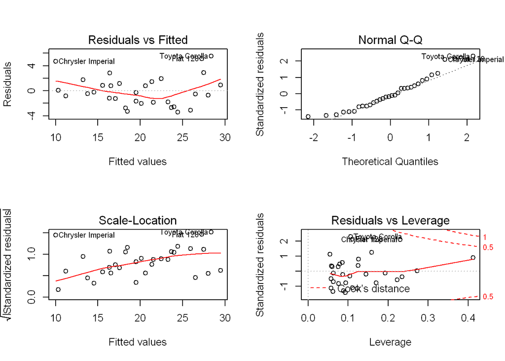

```r
par(mfrow=c(2,2))
plot(fit.hp.wt)
```

Looks like we might have some outliers, chrysler, toyota and fiat. However, overall the residuals show no signifcant pattern. Residuals that are high in value suggest that we might have a right skewed data, as in we have outliers that are showing very high mpg than our model would suggest. We confirm this in a normal Q-Q plot which shows chracteristics of a right-skewness. Looking at cook’s distance, we don’t see any points that are very high in leverage. Overall, we have a fairly good fit although there is some concerns of right skewness.

## Diagnostics for Outliers

We test for outliers to follow up on our concerns.

```r
hatvalues(fit.hp.wt)[order(-hatvalues(fit.hp.wt))]
```

```
##       Maserati Bora Lincoln Continental  Cadillac Fleetwood
##          0.41219678          0.27258474          0.23496391
##   Chrysler Imperial      Ford Pantera L          Duster 360
##          0.23032439          0.22279210          0.19243618
##       Toyota Corona        Lotus Europa          Camaro Z28
##          0.17015873          0.15871278          0.14476256
##           Merc 240D         Honda Civic       Mazda RX4 Wag
##          0.12599131          0.12506709          0.12316145
##            Fiat 128          Volvo 142E      Toyota Corolla
##          0.11134590          0.11126370          0.10653277
##           Fiat X1-9        Ferrari Dino           Mazda RX4
##          0.10399569          0.09383541          0.09320650
##          Datsun 710       Porsche 914-2            Merc 230
##          0.08856401          0.08629737          0.08596393
##   Hornet Sportabout             Valiant      Hornet 4 Drive
##          0.07867173          0.07623258          0.07518198
##            Merc 280           Merc 280C         AMC Javelin
##          0.06309967          0.06309967          0.06183748
##          Merc 450SL          Merc 450SE         Merc 450SLC
##          0.05985811          0.05850151          0.05781436
##    Dodge Challenger    Pontiac Firebird
##          0.05718732          0.05435828
```

Looks like Maserati bora might have a relatively strong potential for leverage.

We will also look at dfbetas for each of our slopes

```r
dfbetas(fit.hp.wt)[,2][which.max(abs(dfbetas(fit.hp.wt)[,2]))]
```

```
## Maserati Bora
##     0.5809822
```

```r
dfbetas(fit.hp.wt)[,3][which.max(abs(dfbetas(fit.hp.wt)[,3]))]
```

```
## Chrysler Imperial
##         0.9726881
```

```r
dfbetas(fit.hp.wt)[,4][which.max(abs(dfbetas(fit.hp.wt)[,4]))]
```

```
## Chrysler Imperial
##         0.5400209
```

The high dfbetas are concerning and it might be helpful to get rid of the outlier’s we identified and fit a new model, Chrysler Imperial, Maserati Bora. To be more careful, we will also remove Fiat 128 and Toyota Corolla. Next, we will fit our new model.

```r
drop.outliers<- c('Chrysler Imperial','Maserati Bora','Fiat 128' ,'Toyota Corolla')
mtcars2 <- mtcars[ !(rownames(mtcars) %in% drop.outliers), ]
fit.hp.wt2 <- lm(mpg~hp+wt+factor(am),mtcars2)
summary(fit.hp.wt)
```

```
##
## Call:
## lm(formula = mpg ~ hp + wt + factor(am), data = mtcars)
##
## Residuals:
##     Min      1Q  Median      3Q     Max
## -3.4221 -1.7924 -0.3788  1.2249  5.5317
##
## Coefficients:
##              Estimate Std. Error t value Pr(>|t|)
## (Intercept) 34.002875   2.642659  12.867 2.82e-13 ***
## hp          -0.037479   0.009605  -3.902 0.000546 ***
## wt          -2.878575   0.904971  -3.181 0.003574 **
## factor(am)1  2.083710   1.376420   1.514 0.141268
## ---
## Signif. codes:  0 '***' 0.001 '**' 0.01 '*' 0.05 '.' 0.1 ' ' 1
##
## Residual standard error: 2.538 on 28 degrees of freedom
## Multiple R-squared:  0.8399, Adjusted R-squared:  0.8227
## F-statistic: 48.96 on 3 and 28 DF,  p-value: 2.908e-11
```

```r
summary(fit.hp.wt2)
```

```
##
## Call:
## lm(formula = mpg ~ hp + wt + factor(am), data = mtcars2)
##
## Residuals:
##     Min      1Q  Median      3Q     Max
## -3.1923 -1.1548 -0.0268  1.2095  3.5206
##
## Coefficients:
##              Estimate Std. Error t value Pr(>|t|)
## (Intercept) 35.916598   2.071252  17.341 4.44e-15 ***
## hp          -0.033822   0.008327  -4.062 0.000451 ***
## wt          -3.624742   0.708938  -5.113 3.12e-05 ***
## factor(am)1  0.268954   1.041020   0.258 0.798335
## ---
## Signif. codes:  0 '***' 0.001 '**' 0.01 '*' 0.05 '.' 0.1 ' ' 1
##
## Residual standard error: 1.8 on 24 degrees of freedom
## Multiple R-squared:  0.892,  Adjusted R-squared:  0.8785
## F-statistic: 66.05 on 3 and 24 DF,  p-value: 9.665e-12
```

Interestingly our new fit suggests that while transmission is still not significant, the p-value when up from .14 to .8. It might have been that the outliers were exercising heavy leverage by having a high mpg as manual vehicles, we check this in our original data.

```r
mtcars[rownames(mtcars) %in% drop.outliers,]
```

```
##                    mpg cyl  disp  hp drat    wt  qsec vs am gear carb
## Chrysler Imperial 14.7   8 440.0 230 3.23 5.345 17.42  0  0    3    4
## Fiat 128          32.4   4  78.7  66 4.08 2.200 19.47  1  1    4    1
## Toyota Corolla    33.9   4  71.1  65 4.22 1.835 19.90  1  1    4    1
## Maserati Bora     15.0   8 301.0 335 3.54 3.570 14.60  0  1    5    8
```

We see that 3 of the outliers we dropped were manual cars. It is very possible that Fiat and Corrolla were skewing the transmission variable by themselves. Maserati Bora’s mpg however is very small but it has a very high horsepower and weight, which reduces the mpg. So, it might be a case that it has a good mpg relative to its high weight and horsepower.

## Answers to the questions

Now we are done with making our model, we will answer the questions asked. “Is an automatic or manual transmission better for MPG” “Quantify the MPG difference between automatic and manual transmissions”

First, I don’t belive that the company should be looking at the transmissions as a variable. As I explained, it is very likely that the outliers were skewing the leverage that transmission variable exerted onto mpg. This was clearly shown by how the variable became statistically insignifcant after having removed the linear effects of horsepower and weight. Also another point to make is that removing the outliers decreased the significance of the transmission even further to a p-value of .8. There is no statistical evidence to think that transmission is significant.

```r
fit.hp.wt2
```

```
##
## Call:
## lm(formula = mpg ~ hp + wt + factor(am), data = mtcars2)
##
## Coefficients:
## (Intercept)           hp           wt  factor(am)1
##    35.91660     -0.03382     -3.62474      0.26895
```

We can see that while manual transmission has no statistical signifiance after having removed the linear effects of weight and horsepower, slope coefficient is still higher for manual vehicles. Manual vehicles get .26895 boost in mpg as shown in the coefficient. So yes, to answer the question while ignoring the drawbacks of the model, manual transmission is expected to get .26895 boost in mpg.

# Appendix

## Exploratory Analysis

Before I begin the analysis, I will first look at the details of the data and plot miles per gallon box plot, split by transmission.

```r
head(mtcars,1)
```

```
##           mpg cyl disp  hp drat   wt  qsec vs am gear carb
## Mazda RX4  21   6  160 110  3.9 2.62 16.46  0  1    4    4
```

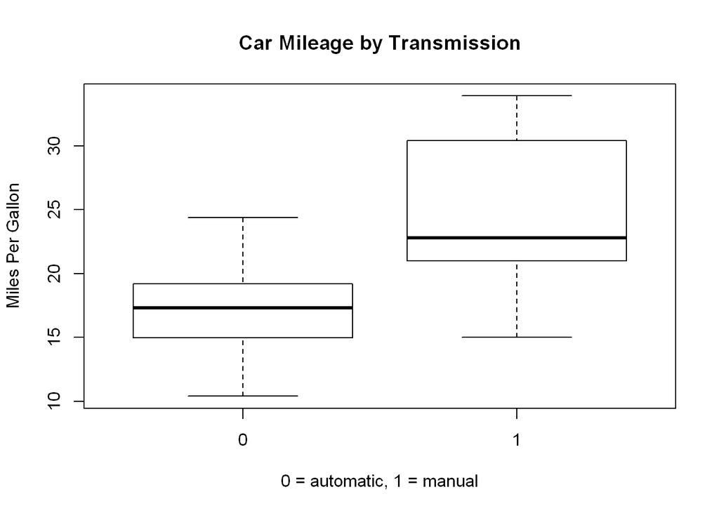

```r
boxplot(mpg~am, data=mtcars, main = "Car Mileage by Transmission", xlab = "0 = automatic, 1 = manual", ylab= "Miles Per Gallon")
```

We see that manual clearly has a lot more miles per gallon in the picture. We will test significance using a linear model. Another point to note is that the data is tricky in a way that manual is 1 and automatic is 0, which was contrary to what I would have thought.

## Work done to comprae different combinations of models

```r
##We add displacement
fit.hp.wt.disp <- lm(mpg~hp+wt+disp+factor(am),mtcars)
anova(fit,fit.hp,fit.hp.wt,fit.hp.wt.disp)

##displacement p-value suggests it might not be significant, we will try everything to make sure we are not excluding any significant variables
fit.hp.wt.drat <- lm(mpg~hp+wt+drat+factor(am),mtcars)
anova(fit,fit.hp,fit.hp.wt,fit.hp.wt.drat)

fit.hp.wt.qsec <- lm(mpg~hp+wt+qsec+factor(am),mtcars)
anova(fit,fit.hp,fit.hp.wt,fit.hp.wt.qsec)

fit.hp.wt.vs <- lm(mpg~hp+wt+factor(vs)+factor(am),mtcars)
anova(fit,fit.hp,fit.hp.wt,fit.hp.wt.vs)

fit.hp.wt.gear <- lm(mpg~hp+wt+factor(gear)+factor(am),mtcars)
anova(fit,fit.hp,fit.hp.wt,fit.hp.wt.gear)

fit.hp.wt.carb <- lm(mpg~hp+wt+factor(carb)+factor(am),mtcars)
anova(fit,fit.hp,fit.hp.wt,fit.hp.wt.carb)
```

[output not shown]